# TEMA 3: DIAGNOSIS DEL MODELO DE REGRESIÓN LINEAL

Aplicación 3.1: El modelo APT (Arbitrage Pricing Theory)

Julián Ramajo, ramajo@unex.es

GRADO EN ESTADÍSTICA | ECONOMETRIA (502243)

# Introducción

En esta aplicación se estimará un modelo de regresión basado en la teoría de los precios de arbitraje (APT). Para más información sobre esta teoría se puede consultar la página: https://es.wikipedia.org/wiki/Teor%C3%ADa_del_arbitraje.

Definamos la rentabilidad de un activo (en porcentaje) como R=100×log((p_1+d)/p_0 ), donde p_1 y p_0 son, respectivamente, los precios de cotización del valor (título u obligación) al final y al principio de un período de tiempo y d es el dividendo cobrado (si lo hay) durante ese período. Denominemos por Rf al rendimiento de un activo libre de riesgo. Finalmente, denotemos por Rm a la rentabilidad que ofrece la cartera de mercado.

En este ejercicio se va a estimar el modelo APT con datos de series temporales de carácter mensual para el período que va desde marzo de 1986 hasta marzo de 2018.

Se utilizará como rentabilidad de referencia la correspondiente a las acciones de la empresa Microsoft, que denotaremos por R_MICROSOFT. Como rentabilidad sin riesgo, se usará el tipo de interés correspondiente a las letras del tesoro estadounidenses a tres meses, R_USTB3M, y como rentabilidad del mercado se tomará la asociada al índice S&P500, R_SP500. Las variables básicas que deben utilizarse en el modelo de regresión son, entonces, los ‘excesos de rentabilidad’, ER_MSOFT=(R_MICROSOFT-R_USTB3M) y ER_SP=(R_SP500-R_USTB3M).

La ecuación de valoración básica del modelo APT puede definirse del siguiente modo:

$$ERMSOFT_{t} = \beta_1 + \beta_2 ERSP_{t} + \gamma_1 F_{1,t} + \gamma_2 F_{2,t} + ...+ \gamma_m F_{m,t} + e_{t}$$
donde las variables *F* representan distintos factores que pueden afectar a la rentabilidad observada del título.

# Código R

```r
library(tidyverse)
library(readxl)
#
macro <- read_excel("APT_MICROSOFT.xls")
dim(macro)
```

```
## [1] 385  10
```

```r
head(macro)
```

```
## # A tibble: 6 × 10
##   Date                MICROSOFT SANDP   CPI INDPRO M1SUPPLY CCREDIT BMINUSA
##   <dttm>                  <dbl> <dbl> <dbl>  <dbl>    <dbl>   <dbl>   <dbl>
## 1 1986-03-01 00:00:00    0.0955  239.  109.   56.5     624.    607.    1.5
## 2 1986-04-01 00:00:00    0.112   236.  109.   56.6     647     614.    1.4
## 3 1986-05-01 00:00:00    0.122   247.  109.   56.7     646.    622.    1.2
## 4 1986-06-01 00:00:00    0.107   251.  110.   56.5     663.    628.    1.21
## 5 1986-07-01 00:00:00    0.0990  236.  110.   56.8     673.    634.    1.28
## 6 1986-08-01 00:00:00    0.0990  253.  110.   56.7     678.    641.    1.46
## # … with 2 more variables: USTB3M <dbl>, USTB10Y <dbl>
```

```r
tail(macro)
```

```
## # A tibble: 6 × 10
##   Date                MICROSOFT SANDP   CPI INDPRO M1SUPPLY CCREDIT BMINUSA
##   <dttm>                  <dbl> <dbl> <dbl>  <dbl>    <dbl>   <dbl>   <dbl>
## 1 2017-10-01 00:00:00      83.2 2575.  247.   105.    3582.   3771.    0.72
## 2 2017-11-01 00:00:00      84.2 2585.  247.   105.    3581.   3805.    0.7
## 3 2017-12-01 00:00:00      85.5 2674.  247.   106.    3636.   3835.    0.71
## 4 2018-01-01 00:00:00      95.0 2824.  248.   105.    3635.   3843.    0.71
## 5 2018-02-01 00:00:00      93.8 2714.  249.   106.    3557.   3827.    0.69
## 6 2018-03-01 00:00:00      91.3 2641.  250.   107.    3685.   3824.    0.77
## # … with 2 more variables: USTB3M <dbl>, USTB10Y <dbl>
```

```r
summary(macro)
```

```
##       Date                       MICROSOFT            SANDP
##  Min.   :1986-03-01 00:00:00   Min.   : 0.09549   Min.   : 230.3
##  1st Qu.:1994-03-01 00:00:00   1st Qu.: 2.89453   1st Qu.: 459.3
##  Median :2002-03-01 00:00:00   Median :25.72000   Median :1104.5
##  Mean   :2002-03-02 01:11:03   Mean   :23.30104   Mean   :1066.0
##  3rd Qu.:2010-03-01 00:00:00   3rd Qu.:30.86000   3rd Qu.:1385.6
##  Max.   :2018-03-01 00:00:00   Max.   :95.01000   Max.   :2823.8
##       CPI            INDPRO          M1SUPPLY         CCREDIT
##  Min.   :108.6   Min.   : 56.50   Min.   : 624.3   Min.   : 606.8
##  1st Qu.:147.2   1st Qu.: 69.48   1st Qu.:1069.3   1st Qu.: 886.2
##  Median :178.8   Median : 93.00   Median :1191.8   Median :1891.8
##  Mean   :181.1   Mean   : 86.63   Mean   :1514.7   Mean   :1897.8
##  3rd Qu.:218.2   3rd Qu.:100.72   3rd Qu.:1716.0   3rd Qu.:2620.5
##  Max.   :249.6   Max.   :106.66   Max.   :3684.7   Max.   :3843.4
##     BMINUSA           USTB3M         USTB10Y
##  Min.   :0.5500   Min.   :0.010   Min.   :1.500
##  1st Qu.:0.7200   1st Qu.:0.450   1st Qu.:3.330
##  Median :0.9000   Median :3.440   Median :4.910
##  Mean   :0.9746   Mean   :3.297   Mean   :5.075
##  3rd Qu.:1.1300   3rd Qu.:5.290   3rd Qu.:6.740
##  Max.   :3.3800   Max.   :9.140   Max.   :9.520
```

```r
#
macro$dspread = c(NA,diff(macro$BMINUSA))
macro$dcredit = c(NA,diff(macro$CCREDIT))
macro$dprod = c(NA,diff(macro$INDPRO))
macro$dmoney = c(NA,diff(macro$M1SUPPLY))
macro$inflation = c(NA,100*diff(log(macro$CPI)))
macro$rterm = c(NA,diff(macro$USTB10Y-macro$USTB3M))
macro$dinflation = c(NA,100*diff(macro$inflation))
macro$r_msoft = c(NA,100*diff(log(macro$MICROSOFT)))
macro$r_sp = c(NA,100*diff(log(macro$SANDP)))
macro$er_sp = c(NA,100*diff(log(macro$SANDP)))-macro$USTB3M/12
macro$er_msoft = c(NA,100*diff(log(macro$MICROSOFT)))-macro$USTB3M/12
# Dar formato a la fechas
macro$Date = as.Date(macro$Date)
#
# ESTIMACIÓN MCO DEL MODELO
#
APT_msoft  <-  lm(er_msoft ~ er_sp + dprod + dcredit + dinflation + dmoney + dspread + rterm, data = macro)
summary(APT_msoft)
```

```
##
## Call:
## lm(formula = er_msoft ~ er_sp + dprod + dcredit + dinflation +
##     dmoney + dspread + rterm, data = macro)
##
## Residuals:
##     Min      1Q  Median      3Q     Max
## -36.075  -4.440  -0.403   4.616  24.480
##
## Coefficients:
##              Estimate Std. Error t value Pr(>|t|)
## (Intercept)  1.326002   0.475481   2.789  0.00556 **
## er_sp        1.280799   0.094354  13.574  < 2e-16 ***
## dprod       -0.303032   0.736881  -0.411  0.68113
## dcredit     -0.025364   0.027149  -0.934  0.35078
## dinflation   0.021947   0.012643   1.736  0.08341 .
## dmoney      -0.006871   0.015568  -0.441  0.65919
## dspread      2.260064   4.140284   0.546  0.58548
## rterm        4.733069   1.715814   2.758  0.00609 **
## ---
## Signif. codes:  0 '***' 0.001 '**' 0.01 '*' 0.05 '.' 0.1 ' ' 1
##
## Residual standard error: 7.845 on 375 degrees of freedom
##   (2 observations deleted due to missingness)
## Multiple R-squared:  0.3452, Adjusted R-squared:  0.333
## F-statistic: 28.24 on 7 and 375 DF,  p-value: < 2.2e-16
```

```r
confint(APT_msoft, level=.95)
```

```
##                    2.5 %      97.5 %
## (Intercept)  0.391060075  2.26094490
## er_sp        1.095268793  1.46632877
## dprod       -1.751968480  1.14590513
## dcredit     -0.078746998  0.02801956
## dinflation  -0.002913344  0.04680674
## dmoney      -0.037482860  0.02373997
## dspread     -5.881018179 10.40114711
## rterm        1.359246340  8.10689139
```

```r
#
# ts_macro <- ts(macro, start=c(1986,3), end=c(2018,3), frequency = 12)
# APT_msoft_ts  <-  lm(er_msoft ~ er_sp + dprod + dcredit + dinflation + dmoney + dspread + rterm, data = ts_macro)
# summary(APT_msoft_ts)
#
# Contraste de hipótesis
# library(car)
# linearHypothesis(APT_msoft_0,c("dprod=0","dcredit=0","dmoney=0","dspread=0"))
#
# DIAGNOSIS DEL MODELO DE REGRESIÓN LIENAL
#
# VALIDACIÓN GLOBAL DE LAS HIPÓTESIS
#
library(gvlma)
gvmodel <- gvlma(APT_msoft)
summary(gvmodel)
```

```
##
## Call:
## lm(formula = er_msoft ~ er_sp + dprod + dcredit + dinflation +
##     dmoney + dspread + rterm, data = macro)
##
## Residuals:
##     Min      1Q  Median      3Q     Max
## -36.075  -4.440  -0.403   4.616  24.480
##
## Coefficients:
##              Estimate Std. Error t value Pr(>|t|)
## (Intercept)  1.326002   0.475481   2.789  0.00556 **
## er_sp        1.280799   0.094354  13.574  < 2e-16 ***
## dprod       -0.303032   0.736881  -0.411  0.68113
## dcredit     -0.025364   0.027149  -0.934  0.35078
## dinflation   0.021947   0.012643   1.736  0.08341 .
## dmoney      -0.006871   0.015568  -0.441  0.65919
## dspread      2.260064   4.140284   0.546  0.58548
## rterm        4.733069   1.715814   2.758  0.00609 **
## ---
## Signif. codes:  0 '***' 0.001 '**' 0.01 '*' 0.05 '.' 0.1 ' ' 1
##
## Residual standard error: 7.845 on 375 degrees of freedom
##   (2 observations deleted due to missingness)
## Multiple R-squared:  0.3452, Adjusted R-squared:  0.333
## F-statistic: 28.24 on 7 and 375 DF,  p-value: < 2.2e-16
##
##
## ASSESSMENT OF THE LINEAR MODEL ASSUMPTIONS
## USING THE GLOBAL TEST ON 4 DEGREES-OF-FREEDOM:
## Level of Significance =  0.05
##
## Call:
##  gvlma(x = APT_msoft)
##
##                        Value   p-value                   Decision
## Global Stat        98.208657 0.000e+00 Assumptions NOT satisfied!
## Skewness            0.002011 9.642e-01    Assumptions acceptable.
## Kurtosis           63.503462 1.554e-15 Assumptions NOT satisfied!
## Link Function       1.601550 2.057e-01    Assumptions acceptable.
## Heteroscedasticity 33.101634 8.747e-09 Assumptions NOT satisfied!
```

```r
#
# CHEQUEO GENERAL DEL MODELO
#
library(performance)
model_performance(APT_msoft)
```

```
## # Indices of model performance
##
## AIC      |      BIC |    R2 | R2 (adj.) |  RMSE | Sigma
## -------------------------------------------------------
## 2674.673 | 2710.205 | 0.345 |     0.333 | 7.762 | 7.845
```

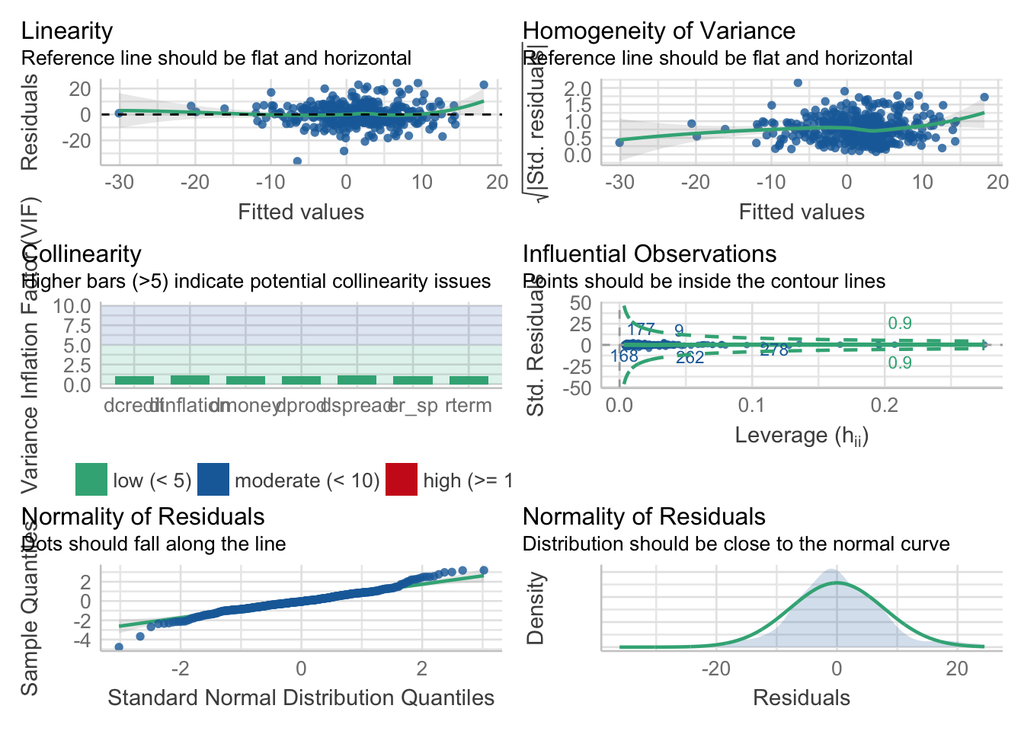

```r
check_model(APT_msoft)
```

```r
# library(lindia)
# gg_diagnose(APT_msoft, plot.all=TRUE)
#
# CHEQUEO INDIVIDUAL DE CADA HIPÓTESIS
#
# ESPECIFICACIÓN DEL MODELO
#
# Forma funcional: test RESET de Ramsey
#
library(lmtest)
resettest(APT_msoft, power=2, type="fitted")
```

```
##
##  RESET test
##
## data:  APT_msoft
## RESET = 1.5705, df1 = 1, df2 = 374, p-value = 0.2109
```

```r
resettest(APT_msoft, power=2:3, type="fitted")
```

```
##
##  RESET test
##
## data:  APT_msoft
## RESET = 1.2908, df1 = 2, df2 = 373, p-value = 0.2763
```

```r
#
# Estabilidad de los parámetros estructurales
#
library(strucchange)
sbtest = Fstats(APT_msoft,data = macro) # Recorte del 15% en ambos lados de la muestra (15% de 383 obs. -> 57)
# Test de Chow con punto de ruptura conocido
JAN1996 = match(as.Date("1996-01-01"),macro$Date)
chow = sbtest$Fstats[JAN1996-2-57] # Punto ruptura (breakpoint): 2 NAs + 57 -> 59
chow
```

```
## [1] 15.32228
```

```r
1-pchisq(chow,sbtest$nreg)
```

```
## [1] 0.05317363
```

```r
# Test de Chow recursivo (punto de ruptura desconocido)
sctest(sbtest)
```

```
##
##  supF test
##
## data:  sbtest
## sup.F = 32.465, p-value = 0.002149
```

```r
bp = which.max(sbtest$Fstats)+59
macro$Date[bp]
```

```
## [1] "2001-05-01"
```

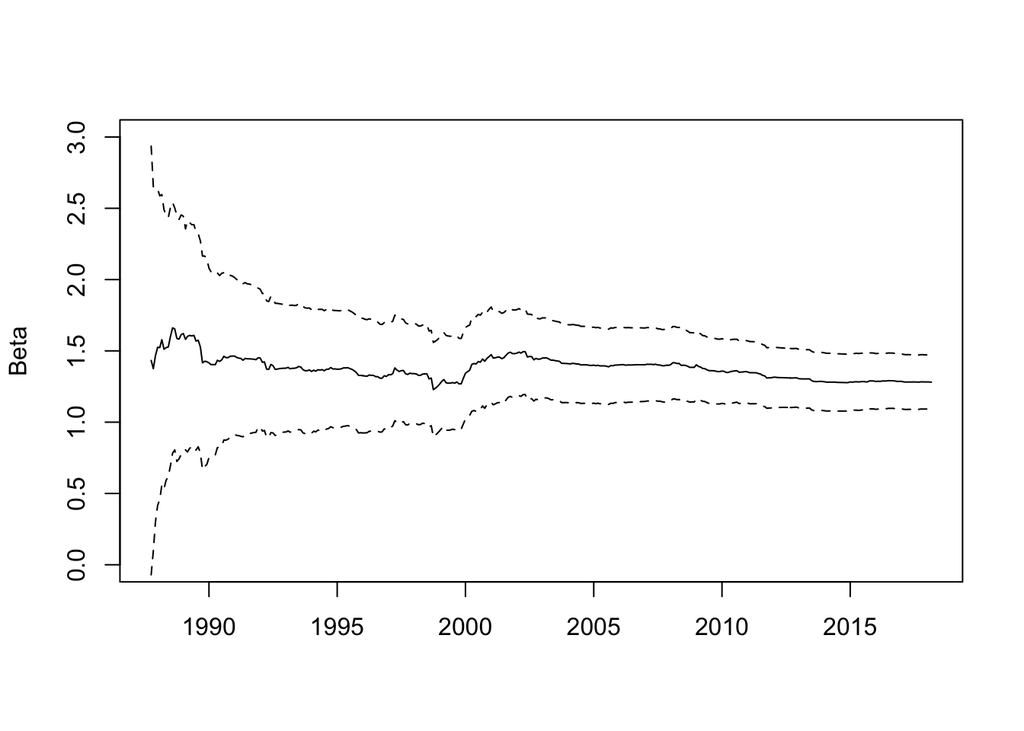

```r
# Estimación recursiva y test CUSUM
# Parámetros recursivos
beta = NULL # variable para introducir en cada paso el beta y su error estándar estimados
for (t in 20:nrow(macro)){
  lr = summary(lm(formula(APT_msoft), data = macro[3:t,]))
  beta = rbind(beta,lr$coefficients["er_sp",1:2])
  }
x_axis = macro$Date[20:nrow(macro)]
plot(x_axis,beta[,1],type = "l",ylim = c(0,3),xlab="",ylab="Beta")
lines(x_axis,beta[,1]+2*beta[,2],lty="dashed")
lines(x_axis,beta[,1]-2*beta[,2],lty="dashed")
```

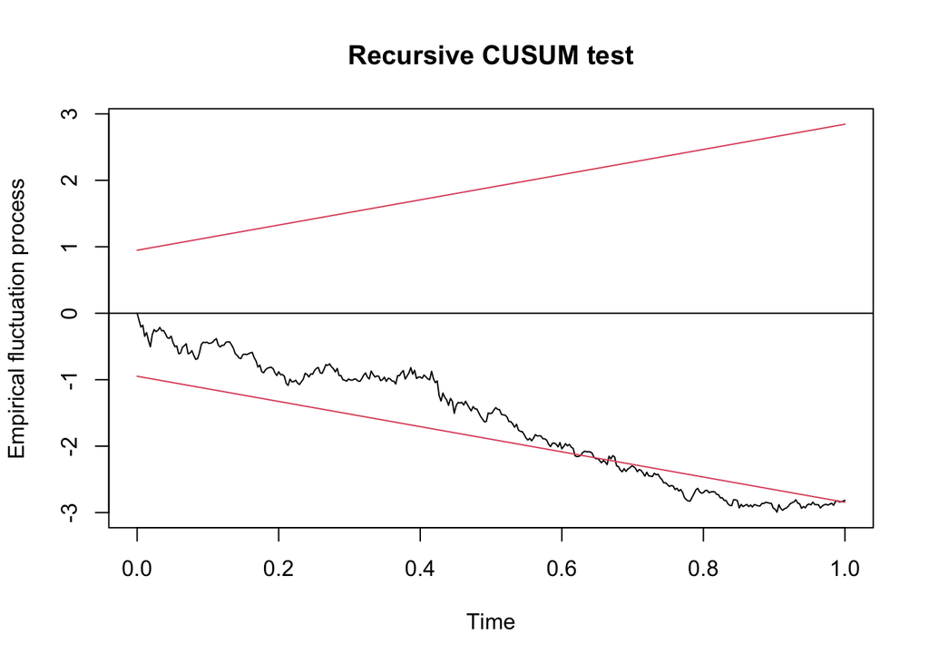

```r
# Test CUSUM
plot(efp(APT_msoft,data=macro))
```

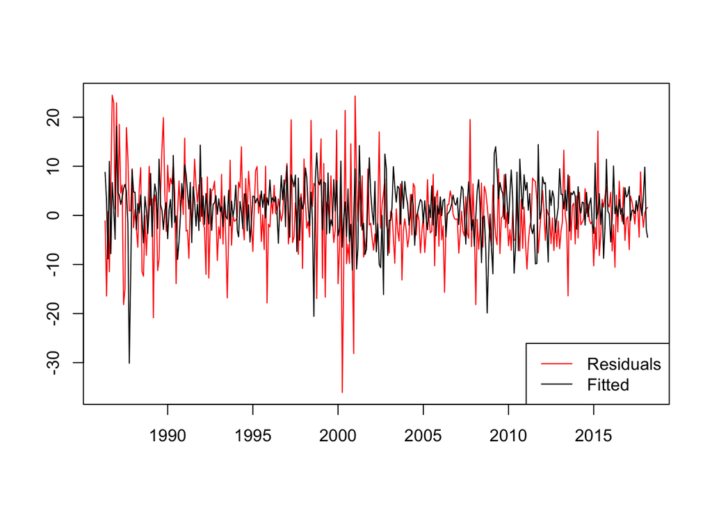

```r
# Cambio estructural y datos atípicos
# Sucesos especiales (uso de variables ficticias para modelizar la presencia de outliers aislados)
plot(macro$Date[-(1:2)],APT_msoft$residuals,type = "l", col="red",xlab="",ylab="")
lines(macro$Date[-(1:2)],APT_msoft$fitted.values)
legend("bottomright",c("Residuals","Fitted"), col = c("red","black"),lty=1)
```

```r
#
macro$APR2000DUM = as.integer(macro$Date == as.Date("2000-04-01"))
macro$DEC2000DUM = as.integer(macro$Date == as.Date("2000-12-01"))
APT_msft_dummy = lm(er_msoft ~ er_sp + dprod + dcredit + dinflation + dmoney + dspread + rterm + APR2000DUM + DEC2000DUM, data = macro)
summary(APT_msft_dummy)
```

```
##
## Call:
## lm(formula = er_msoft ~ er_sp + dprod + dcredit + dinflation +
##     dmoney + dspread + rterm + APR2000DUM + DEC2000DUM, data = macro)
##
## Residuals:
##      Min       1Q   Median       3Q      Max
## -20.9130  -4.3820  -0.4323   4.2993  25.0430
##
## Coefficients:
##               Estimate Std. Error t value Pr(>|t|)
## (Intercept)   1.419760   0.454388   3.125 0.001920 **
## er_sp         1.253853   0.090222  13.897  < 2e-16 ***
## dprod        -0.321131   0.704945  -0.456 0.648985
## dcredit      -0.015718   0.026044  -0.603 0.546548
## dinflation    0.014421   0.012146   1.187 0.235889
## dmoney       -0.005696   0.014868  -0.383 0.701875
## dspread       1.869289   3.955274   0.473 0.636770
## rterm         4.264174   1.640514   2.599 0.009712 **
## APR2000DUM  -37.028834   7.576018  -4.888 1.52e-06 ***
## DEC2000DUM  -28.729950   7.546383  -3.807 0.000164 ***
## ---
## Signif. codes:  0 '***' 0.001 '**' 0.01 '*' 0.05 '.' 0.1 ' ' 1
##
## Residual standard error: 7.492 on 373 degrees of freedom
##   (2 observations deleted due to missingness)
## Multiple R-squared:  0.406,  Adjusted R-squared:  0.3917
## F-statistic: 28.33 on 9 and 373 DF,  p-value: < 2.2e-16
```

```r
# Períodos especiales (conocidos a priori)
require(lubridate)
macro$JANDUM = as.integer(month(macro$Date) == 1)
summary(lm(er_msoft ~  er_sp + dprod + dcredit + dinflation + dmoney + dspread + rterm + APR2000DUM + DEC2000DUM + JANDUM, data = macro))
```

```
##
## Call:
## lm(formula = er_msoft ~ er_sp + dprod + dcredit + dinflation +
##     dmoney + dspread + rterm + APR2000DUM + DEC2000DUM + JANDUM,
##     data = macro)
##
## Residuals:
##      Min       1Q   Median       3Q      Max
## -20.4552  -4.4790  -0.2029   4.2176  24.1128
##
## Coefficients:
##               Estimate Std. Error t value Pr(>|t|)
## (Intercept)   1.044217   0.494169   2.113 0.035260 *
## er_sp         1.246083   0.090002  13.845  < 2e-16 ***
## dprod        -0.284948   0.702759  -0.405 0.685365
## dcredit      -0.010314   0.026110  -0.395 0.693045
## dinflation    0.002301   0.013686   0.168 0.866589
## dmoney        0.002951   0.015501   0.190 0.849110
## dspread       1.188033   3.957871   0.300 0.764215
## rterm         4.209344   1.635079   2.574 0.010427 *
## APR2000DUM  -37.797619   7.560603  -4.999 8.88e-07 ***
## DEC2000DUM  -28.862340   7.520532  -3.838 0.000146 ***
## JANDUM        3.139099   1.654212   1.898 0.058518 .
## ---
## Signif. codes:  0 '***' 0.001 '**' 0.01 '*' 0.05 '.' 0.1 ' ' 1
##
## Residual standard error: 7.466 on 372 degrees of freedom
##   (2 observations deleted due to missingness)
## Multiple R-squared:  0.4117, Adjusted R-squared:  0.3959
## F-statistic: 26.04 on 10 and 372 DF,  p-value: < 2.2e-16
```

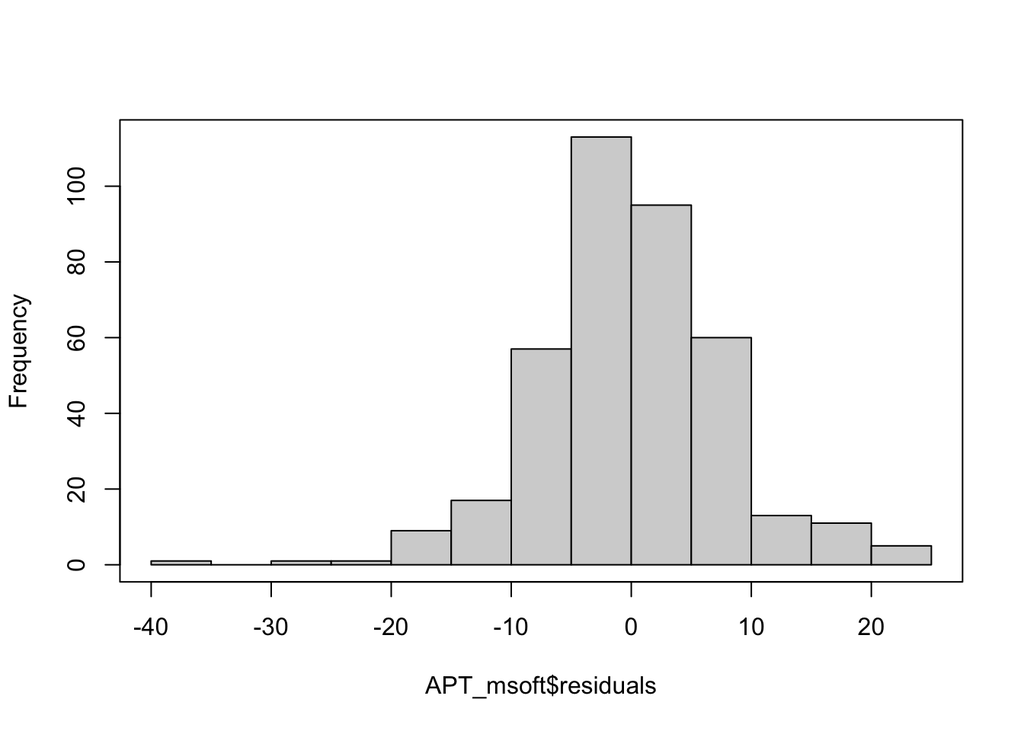

```r
#
# TÉRMINO DE ERROR DEL MODELO
#
# Normalidad  de los errores
#
# Histograma de los residuos
hist(APT_msoft$residuals,main = "")
box()
```

```r
# Estadísticos de normalidad
library(moments)
skewness(APT_msoft$residuals)
```

```
## [1] -0.005612677
```

```r
kurtosis(APT_msoft$residuals)
```

```
## [1] 4.994826
```

```r
jarque.test(APT_msoft$residuals)
```

```
##
##  Jarque-Bera Normality Test
##
## data:  APT_msoft$residuals
## JB = 63.505, p-value = 1.621e-14
## alternative hypothesis: greater
```

```r
agostino.test(APT_msoft$residuals)
```

```
##
##  D'Agostino skewness test
##
## data:  APT_msoft$residuals
## skew = -0.0056127, z = -0.0456821, p-value = 0.9636
## alternative hypothesis: data have a skewness
```

```r
anscombe.test(APT_msoft$residuals)
```

```
##
##  Anscombe-Glynn kurtosis test
##
## data:  APT_msoft$residuals
## kurt = 4.9948, z = 4.5984, p-value = 4.258e-06
## alternative hypothesis: kurtosis is not equal to 3
```

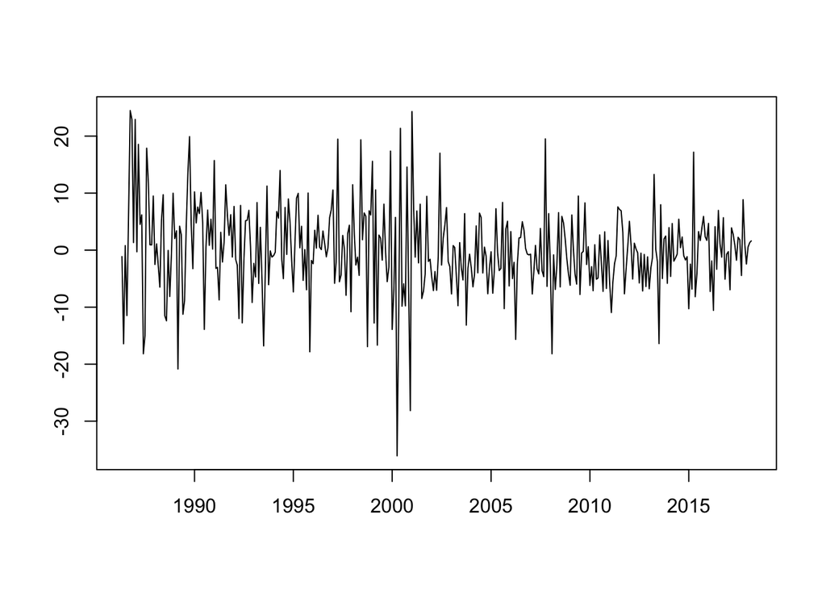

```r
#
# Heteroscedasticidad
#
# Gráfico de errores estimados (residuos)
plot(macro$Date[-(1:2)],APT_msoft$residuals,type = "l",xlab="",ylab="")
```

```r
# Test de White
library(skedastic)
white_lm(APT_msoft)
```

```
## # A tibble: 1 × 5
##   statistic p.value parameter method       alternative
##       <dbl>   <dbl>     <dbl> <chr>        <chr>
## 1      9.84   0.774        14 White's Test greater
```

```r
white_lm(APT_msoft, interactions = TRUE)
```

```
## # A tibble: 1 × 5
##   statistic p.value parameter method       alternative
##       <dbl>   <dbl>     <dbl> <chr>        <chr>
## 1      37.5   0.357        35 White's Test greater
```

```r
# Test de Breusch-Pagan de heteroscedasticidad aditiva
library(skedastic)
glejser(APT_msoft)
```

```
## # A tibble: 1 × 4
##   statistic p.value parameter alternative
##       <dbl>   <dbl>     <dbl> <chr>
## 1      7.53   0.376         7 greater
```

```r
breusch_pagan(APT_msoft)
```

```
## # A tibble: 1 × 5
##   statistic p.value parameter method                alternative
##       <dbl>   <dbl>     <dbl> <chr>                 <chr>
## 1      3.16   0.870         7 Koenker (studentised) greater
```

```r
library(lmtest)
bptest(formula(APT_msoft),data = macro,studentize = F)
```

```
##
##  Breusch-Pagan test
##
## data:  formula(APT_msoft)
## BP = 6.3131, df = 7, p-value = 0.5037
```

```r
bptest(formula(APT_msoft),data = macro,studentize = T)
```

```
##
##  studentized Breusch-Pagan test
##
## data:  formula(APT_msoft)
## BP = 3.1607, df = 7, p-value = 0.8698
```

```r
#
# Heteroscedasticidad autorregresiva condicional (ARCH)
#
library(FinTS)
# Test de Engle
ArchTest(APT_msoft$residuals , lags = 1)
```

```
##
##  ARCH LM-test; Null hypothesis: no ARCH effects
##
## data:  APT_msoft$residuals
## Chi-squared = 7.2188, df = 1, p-value = 0.007214
```

```r
# Corrección de la matriz de covarianzas (MCO corregidos)
library(sandwich)
coeftest(APT_msoft,vcov. = vcovHC(APT_msoft,type="HC1")) # Corrección de White
```

```
##
## t test of coefficients:
##
##               Estimate Std. Error t value  Pr(>|t|)
## (Intercept)  1.3260025  0.4590678  2.8885  0.004096 **
## er_sp        1.2807988  0.0929615 13.7777 < 2.2e-16 ***
## dprod       -0.3030317  0.6345495 -0.4776  0.633246
## dcredit     -0.0253637  0.0208151 -1.2185  0.223790
## dinflation   0.0219467  0.0130680  1.6794  0.093903 .
## dmoney      -0.0068714  0.0109006 -0.6304  0.528835
## dspread      2.2600645  3.4278130  0.6593  0.510088
## rterm        4.7330689  1.7265468  2.7413  0.006412 **
## ---
## Signif. codes:  0 '***' 0.001 '**' 0.01 '*' 0.05 '.' 0.1 ' ' 1
```

```r
#
# Autocorrelación
#
# Test de Durbin-Watson
dwtest(APT_msoft)
```

```
##
##  Durbin-Watson test
##
## data:  APT_msoft
## DW = 2.0974, p-value = 0.8176
## alternative hypothesis: true autocorrelation is greater than 0
```

```r
# Test de Breusch-Godfrey
bgtest(APT_msoft,order = 1)
```

```
##
##  Breusch-Godfrey test for serial correlation of order up to 1
##
## data:  APT_msoft
## LM test = 0.9347, df = 1, p-value = 0.3336
```

```r
bgtest(APT_msoft,order = 6)
```

```
##
##  Breusch-Godfrey test for serial correlation of order up to 6
##
## data:  APT_msoft
## LM test = 3.0501, df = 6, p-value = 0.8025
```

```r
# Corrección de la matriz de covarianzas
library(sandwich)
coeftest(APT_msoft,vcov. = NeweyWest(APT_msoft,lag = 6,adjust = T,prewhite = F)) # Corrección de Newey-West
```

```
##
## t test of coefficients:
##
##               Estimate Std. Error t value  Pr(>|t|)
## (Intercept)  1.3260025  0.5027048  2.6377  0.008694 **
## er_sp        1.2807988  0.0998922 12.8218 < 2.2e-16 ***
## dprod       -0.3030317  0.5216170 -0.5809  0.561625
## dcredit     -0.0253637  0.0223410 -1.1353  0.256975
## dinflation   0.0219467  0.0131362  1.6707  0.095614 .
## dmoney      -0.0068714  0.0109474 -0.6277  0.530596
## dspread      2.2600645  2.8418132  0.7953  0.426948
## rterm        4.7330689  1.7585143  2.6915  0.007431 **
## ---
## Signif. codes:  0 '***' 0.001 '**' 0.01 '*' 0.05 '.' 0.1 ' ' 1
```

```r
#
# Multicolinealidad
#
library(car)
library(corrplot)
# Matriz de correlaciones
cor(macro[-(1:2),c("er_sp","dprod","dcredit","dinflation","dmoney","dspread","rterm")])
```

```
##                  er_sp       dprod      dcredit  dinflation       dmoney
## er_sp       1.00000000 -0.01678420  0.047664705 -0.00228811  0.036726343
## dprod      -0.01678420  1.00000000  0.094273354 -0.14355079 -0.052514358
## dcredit     0.04766470  0.09427335  1.000000000 -0.02460369  0.150165099
## dinflation -0.00228811 -0.14355079 -0.024603694  1.00000000 -0.093571291
## dmoney      0.03672634 -0.05251436  0.150165099 -0.09357129  1.000000000
## dspread    -0.17628529 -0.05275628  0.062818012 -0.22710010  0.170698675
## rterm      -0.04564889 -0.04375067 -0.004029469  0.04160626  0.003800624
##                dspread        rterm
## er_sp      -0.17628529 -0.045648891
## dprod      -0.05275628 -0.043750669
## dcredit     0.06281801 -0.004029469
## dinflation -0.22710010  0.041606256
## dmoney      0.17069868  0.003800624
## dspread     1.00000000 -0.017622374
## rterm      -0.01762237  1.000000000
```

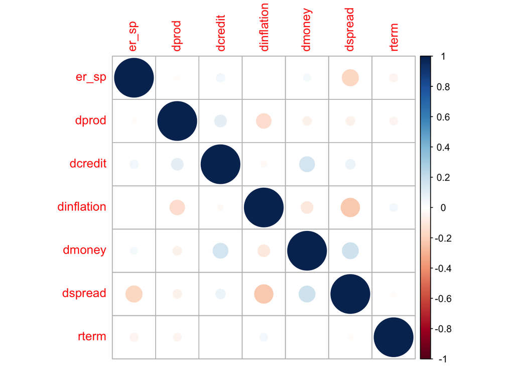

```r
corrplot(cor(macro[-(1:2),c("er_sp","dprod","dcredit","dinflation","dmoney","dspread","rterm")]))
```

```r
# FIVs
vif(APT_msoft)
```

```
##      er_sp      dprod    dcredit dinflation     dmoney    dspread      rterm
##   1.045330   1.047018   1.039351   1.090154   1.062975   1.132181   1.005900
```

# Código Python

```python
import pandas as pd
import numpy as np
import statsmodels.api as sm
import statsmodels.formula.api as smf
import statsmodels.stats.api as sms
from statsmodels.stats.diagnostic import het_arch
from statsmodels.stats.outliers_influence import reset_ramsey
from statsmodels.compat import lzip
import scipy.stats as scs
import matplotlib.pyplot as plt
import seaborn as sns
#
macro = pd.read_excel('APT_MICROSOFT.xls', index_col=0)
macro.head()
```

```
##             MICROSOFT       SANDP    CPI  ...  BMINUSA  USTB3M  USTB10Y
## Date                                      ...
## 1986-03-01   0.095486  238.899994  108.8  ...     1.50    6.76     7.78
## 1986-04-01   0.111979  235.520004  108.6  ...     1.40    6.24     7.30
## 1986-05-01   0.121528  247.350006  108.9  ...     1.20    6.33     7.71
## 1986-06-01   0.106771  250.839996  109.5  ...     1.21    6.40     7.80
## 1986-07-01   0.098958  236.119995  109.5  ...     1.28    6.00     7.30
##
## [5 rows x 9 columns]
```

```python
macro.tail()
#
```

```
##             MICROSOFT        SANDP      CPI  ...  BMINUSA  USTB3M  USTB10Y
## Date                                         ...
## 2017-11-01  84.169998  2584.840088  246.669  ...     0.70    1.25     2.35
## 2017-12-01  85.540001  2673.610107  246.524  ...     0.71    1.34     2.40
## 2018-01-01  95.010002  2823.810059  247.867  ...     0.71    1.43     2.58
## 2018-02-01  93.769997  2713.830078  248.991  ...     0.69    1.59     2.86
## 2018-03-01  91.269997  2640.870117  249.554  ...     0.77    1.73     2.84
##
## [5 rows x 9 columns]
```

```python
def LogDiff(x):
    x_diff = 100*np.log(x/x.shift(1))
    return x_diff
data = pd.DataFrame({'dspread' : macro['BMINUSA'] - macro['BMINUSA'].shift(1),
                    'dcredit' : macro['CCREDIT'] - macro['CCREDIT'].shift(1),
                    'dprod' : macro['INDPRO'] - macro['INDPRO'].shift(1),
                    'r_msoft' : LogDiff(macro['MICROSOFT']),
                    'r_sp' : LogDiff(macro['SANDP']),
                    'dmoney' : macro['M1SUPPLY'] - macro['M1SUPPLY'].shift(1),
                    'inflation' : LogDiff(macro['CPI']),
                    'term' : macro['USTB10Y'] - macro['USTB3M'],
                    'dinflation' : LogDiff(macro['CPI']) - LogDiff(macro['CPI']).shift(1),
                    'mustb3m' : macro['USTB3M']/12,
                    'rterm' : (macro['USTB10Y'] - macro['USTB3M']) - (macro['USTB10Y'] - macro['USTB3M']).shift(1),
                    'er_msoft' : LogDiff(macro['MICROSOFT']) - macro['USTB3M']/12,
                    'er_sp' : LogDiff(macro['SANDP']) - macro['USTB3M']/12})
data = data.dropna()
#
# ESTIMACIÓN MCO DEL MODELO
#
formula = 'er_msoft ~ er_sp + dprod + dcredit + dinflation + dmoney + dspread + rterm'
results = smf.ols(formula, data).fit()
print(results.summary())
# Contraste de hipótesis
# hypotheses = 'dprod = dcredit = dmoney = dspread = 0'
# F_test = results.f_test(hypotheses)
# print(F_test)
#
# DIGANOSIS DEL MODELO
#
# ESPECIFICACIÓN DEL MODELO
#
# Forma funcional: test RESET de Ramsey
```

```
##                             OLS Regression Results
## ==============================================================================
## Dep. Variable:               er_msoft   R-squared:                       0.345
## Model:                            OLS   Adj. R-squared:                  0.333
## Method:                 Least Squares   F-statistic:                     28.24
## Date:                lun, 29 nov 2021   Prob (F-statistic):           3.52e-31
## Time:                        19:27:25   Log-Likelihood:                -1328.3
## No. Observations:                 383   AIC:                             2673.
## Df Residuals:                     375   BIC:                             2704.
## Df Model:                           7
## Covariance Type:            nonrobust
## ==============================================================================
##                  coef    std err          t      P>|t|      [0.025      0.975]
## ------------------------------------------------------------------------------
## Intercept      1.3260      0.475      2.789      0.006       0.391       2.261
## er_sp          1.2808      0.094     13.574      0.000       1.095       1.466
## dprod         -0.3030      0.737     -0.411      0.681      -1.752       1.146
## dcredit       -0.0254      0.027     -0.934      0.351      -0.079       0.028
## dinflation     2.1947      1.264      1.736      0.083      -0.291       4.681
## dmoney        -0.0069      0.016     -0.441      0.659      -0.037       0.024
## dspread        2.2601      4.140      0.546      0.585      -5.881      10.401
## rterm          4.7331      1.716      2.758      0.006       1.359       8.107
## ==============================================================================
## Omnibus:                       21.147   Durbin-Watson:                   2.097
## Prob(Omnibus):                  0.000   Jarque-Bera (JB):               63.505
## Skew:                          -0.006   Prob(JB):                     1.62e-14
## Kurtosis:                       4.995   Cond. No.                         293.
## ==============================================================================
##
## Notes:
## [1] Standard Errors assume that the covariance matrix of the errors is correctly specified.
```

```python
reset_ramsey(results,degree=2)
```

```
## <class 'statsmodels.stats.contrast.ContrastResults'>
## <F test: F=array([[1.570483]]), p=0.21091977906719167, df_denom=374, df_num=1>
```

```python
reset_ramsey(results,degree=3)
#
# Estabilidad de los parámetros
#
# Test de Chow (punto de ruptura conocido)
# Definición del test de Chow
#    inputs:
#       data: a pandas DataFrame of independent and dependent variable
#    outputs:
#        rss: the sum of residuals
#        N: the observations of inputs
#        K: total number of parameters
#
```

```
## <class 'statsmodels.stats.contrast.ContrastResults'>
## <F test: F=array([[1.29084016]]), p=0.27626535022759807, df_denom=373, df_num=2>
```

```python
def get_rss(data):
    formula = 'er_msoft ~ er_sp + dprod + dcredit + dinflation + dmoney + dspread + rterm'
    results = smf.ols(formula, data).fit()
    rss = (results.resid**2).sum() # obtain the residuals sum of square
    N = results.nobs
    K = results.df_model
    return rss, N, K
# División por submuestras (split samples)
data1 = data[:'1996-01-01']
data2 = data['1996-01-01':]
# Muestra completa
RSS_total, N_total, K_total = get_rss(data)
# Primera submuestra
RSS_1, N_1, K_1 = get_rss(data1)
# Segunda submuestra
RSS_2, N_2, K_2 = get_rss(data2)
# Estadístico de contraste
nominator = (RSS_total - (RSS_1 + RSS_2)) / K_total
denominator = (RSS_1 + RSS_2) / (N_1 + N_2 - 2*K_total)
result = nominator/denominator
#
result
#
# Test de Chow recursivo (punto de ruptura desconocido)
```

```
## 1.9894610789616354
```

```python
name = ['test statistic', 'pval', 'crit']
test = sms.breaks_cusumolsresid(resid = results.resid, ddof = results.df_model)
lzip(name, test)
# Estimación recursiva y test CUSUM
```

```
## [('test statistic', 1.5352572458140457), ('pval', 0.017937116553892667), ('crit', [(1, 1.63), (5, 1.36), (10, 1.22)])]
```

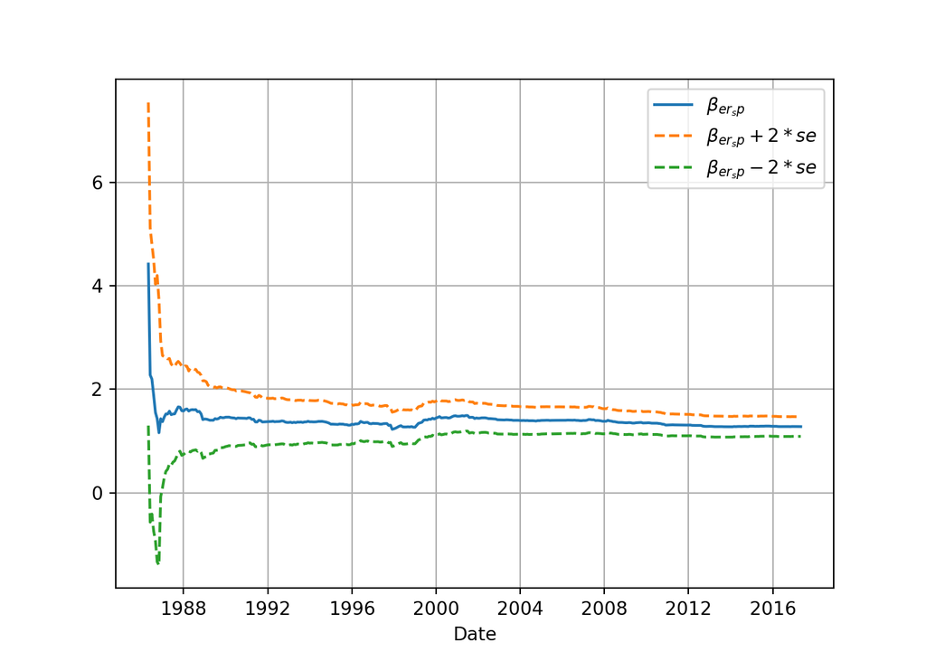

```python
data = data.dropna()
# Definición de los estadísticos recursivos
#
#    inputs:
#        variable: the string literals of a variable name in regression formula
#        i: the serial number of regression
#        interval: the number of consective data points in initial sample
#    outputs:
#        coeff: the coefficient estimation of the variable
#        se: the standard errors of the variable
#
def recursive_reg(variable, i, interval):
    formula = 'er_msoft ~ er_sp + dprod + dcredit + dinflation + dmoney + dspread + rterm'
    results = smf.ols(formula, data.iloc[:i+interval]).fit()
    coeff = results.params[variable]
    se = results.bse[variable]
    return coeff, se
#
parameters = []
for i in range(373):
    coeff, se = recursive_reg('er_sp', i, 11)
    parameters.append((coeff,se))
parameters = pd.DataFrame(parameters, columns=['coeff','se'], index = data[:-10].index)
parameters['er_sp + 2*se'] = parameters['coeff'] + 2*parameters['se']
parameters['er_sp - 2*se'] = parameters['coeff'] - 2*parameters['se']
#
plt.figure(1)
plt.plot(parameters['coeff'], label=r'$\beta_{er_sp}$')
plt.plot(parameters['er_sp + 2*se'], label=r'$\beta_{er_sp} + 2*se$', linestyle='dashed')
plt.plot(parameters['er_sp - 2*se'], label=r'$\beta_{er_sp} - 2*se$', linestyle='dashed')
plt.xlabel('Date')
plt.grid(True)
plt.legend()
plt.show()
# Modelización de sucesos especiales (uso de variables ficticias para tratar la presencia de outliers aislados)
```

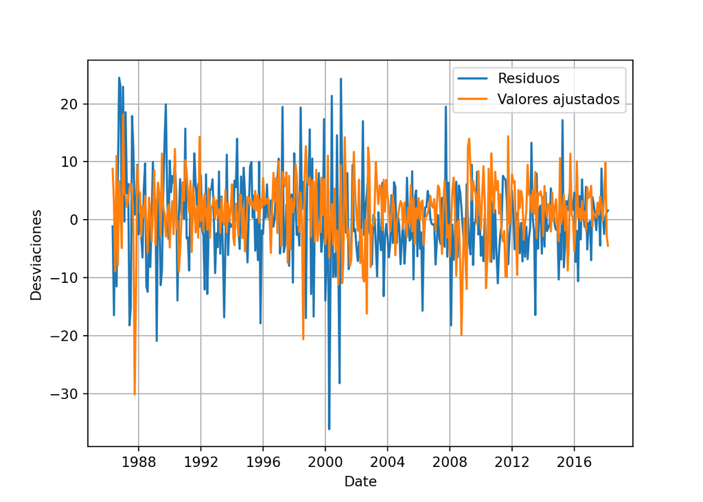

```python
y_fitted = results.fittedvalues
residuals = results.resid
#
plt.figure(2)
plt.plot(residuals, label='Residuos')
plt.plot(y_fitted, label='Valores ajustados')
plt.xlabel('Date')
plt.ylabel('Desviaciones')
plt.grid(True)
plt.legend()
plt.show()
# Identificación de valores menores
```

```python
residuals.nsmallest(2)
#
```

```
## Date
## 2000-04-01   -36.075347
## 2000-12-01   -28.143156
## dtype: float64
```

```python
data['APR2000DUM'] = np.where(data.index == '2000-4-1', 1, 0)
data['DEC2000DUM'] = np.where(data.index == '2000-12-1', 1, 0)
#
formula = 'er_msoft ~ er_sp + dprod + dcredit + dinflation + dmoney + dspread + rterm + APR2000DUM + DEC2000DUM'
results = smf.ols(formula, data).fit()
print(results.summary())
#
# TÉRMINO DE ERROR DEL MODELO
#
# Normalidad de los errores
#
```

```
##                             OLS Regression Results
## ==============================================================================
## Dep. Variable:               er_msoft   R-squared:                       0.406
## Model:                            OLS   Adj. R-squared:                  0.392
## Method:                 Least Squares   F-statistic:                     28.33
## Date:                lun, 29 nov 2021   Prob (F-statistic):           2.22e-37
## Time:                        19:27:34   Log-Likelihood:                -1309.7
## No. Observations:                 383   AIC:                             2639.
## Df Residuals:                     373   BIC:                             2679.
## Df Model:                           9
## Covariance Type:            nonrobust
## ==============================================================================
##                  coef    std err          t      P>|t|      [0.025      0.975]
## ------------------------------------------------------------------------------
## Intercept      1.4198      0.454      3.125      0.002       0.526       2.313
## er_sp          1.2539      0.090     13.897      0.000       1.076       1.431
## dprod         -0.3211      0.705     -0.456      0.649      -1.707       1.065
## dcredit       -0.0157      0.026     -0.603      0.547      -0.067       0.035
## dinflation     1.4421      1.215      1.187      0.236      -0.946       3.830
## dmoney        -0.0057      0.015     -0.383      0.702      -0.035       0.024
## dspread        1.8693      3.955      0.473      0.637      -5.908       9.647
## rterm          4.2642      1.641      2.599      0.010       1.038       7.490
## APR2000DUM   -37.0288      7.576     -4.888      0.000     -51.926     -22.132
## DEC2000DUM   -28.7300      7.546     -3.807      0.000     -43.569     -13.891
## ==============================================================================
## Omnibus:                       20.084   Durbin-Watson:                   2.088
## Prob(Omnibus):                  0.000   Jarque-Bera (JB):               28.877
## Skew:                           0.404   Prob(JB):                     5.36e-07
## Kurtosis:                       4.076   Cond. No.                         560.
## ==============================================================================
##
## Notes:
## [1] Standard Errors assume that the covariance matrix of the errors is correctly specified.
```

```python
residuals = results.resid
# Histograma de los residuos
plt.figure(3)
plt.hist(residuals,20,edgecolor='black',linewidth=1.2)
```

```
## (array([ 1.,  8.,  3.,  8., 11., 20., 38., 47., 58., 57., 36., 41., 21.,
##        11.,  4.,  3.,  6.,  5.,  2.,  3.]), array([-20.91295669, -18.6151597 , -16.31736271, -14.01956572,
##        -11.72176873,  -9.42397173,  -7.12617474,  -4.82837775,
##         -2.53058076,  -0.23278377,   2.06501322,   4.36281021,
##          6.66060721,   8.9584042 ,  11.25620119,  13.55399818,
##         15.85179517,  18.14959216,  20.44738915,  22.74518615,
##         25.04298314]), <BarContainer object of 20 artists>)
```

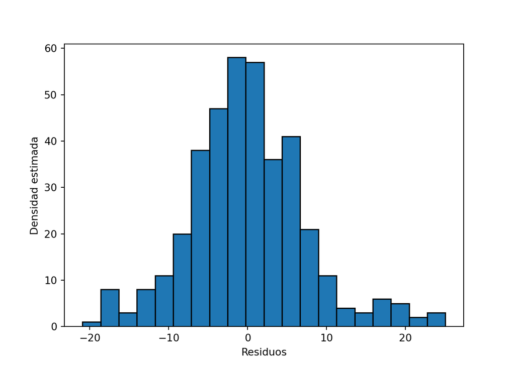

```python
plt.xlabel('Residuos')
plt.ylabel('Densidad estimada')
plt.show()
# Test de Jarque-Bera
```

```python
name = ['Jarque-Bera', 'Chi^2 two-tail prob.', 'Skewness', 'Kurtosis']
JB_test = sms.jarque_bera(residuals)
lzip(name, JB_test)
# Contrastes de normalidad para una variable (var: ndarray)
```

```
## [('Jarque-Bera', 28.87694455661331), ('Chi^2 two-tail prob.', 5.363535536503574e-07), ('Skewness', 0.40368594973354516), ('Kurtosis', 4.075951646622296)]
```

```python
def normality_tests(var):
  Skewness_test = scs.skew(var)
  Skewness_pvalue = scs.skewtest(var)[1]
  Kurtosis_test = scs.kurtosis(var)
  Kurtosis_pvalue = scs.kurtosistest(var)[1]
  Normality_test = scs.normaltest(var)
  return Skewness_test, Skewness_pvalue, Kurtosis_test, Kurtosis_pvalue, Normality_test
#
print(normality_tests(residuals))
#
```

```
## (0.40368594973354516, 0.0015199126026209612, 1.075951646622296, 0.0015406686789649943, NormaltestResult(statistic=20.08365055289113, pvalue=4.354022752810841e-05))
```

```python
name = ['Skewness_test', 'Skewness_pvalue', 'Kurtosis_test', 'Kurtosis_pvalue', 'Normality_test']
ntests = normality_tests(residuals)
lzip(name, ntests)
#
# Heteroscedasticidad
#
# Gráfico de errores estimados (residuos)
```

```
## [('Skewness_test', 0.40368594973354516), ('Skewness_pvalue', 0.0015199126026209612), ('Kurtosis_test', 1.075951646622296), ('Kurtosis_pvalue', 0.0015406686789649943), ('Normality_test', NormaltestResult(statistic=20.08365055289113, pvalue=4.354022752810841e-05))]
```

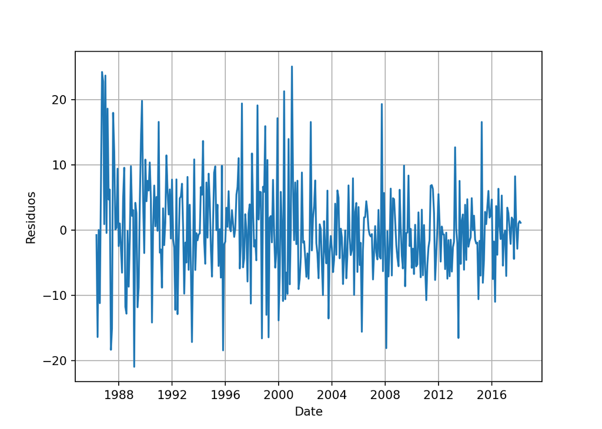

```python
plt.figure(4)
plt.plot(results.resid)
plt.xlabel('Date')
plt.ylabel('Residuos')
plt.grid(True)
plt.show()
# Test de White
```

```python
name = ['Lagrange multiplier statistic', 'p-value',
        'f-value', 'f p-value']
W_test = sms.het_white(results.resid, results.model.exog)
lzip(name, W_test)
# Test de Breusch-Pagan (heter. aditiva)
```

```
## [('Lagrange multiplier statistic', 42.35930015948545), ('p-value', 0.25081005180261295), ('f-value', 1.1594969509614328), ('f p-value', 0.2477915201199085)]
```

```python
name = ['Lagrange multiplier statistic', 'p-value',
        'f-value', 'f p-value']
BP_test = sms.het_breuschpagan(results.resid, results.model.exog)
lzip(name, BP_test)
# Heteroscedasticidad autorregresiva condicional (ARCH): test de Engle
```

```
## [('Lagrange multiplier statistic', 13.503823336155298), ('p-value', 0.14110213712943817), ('f-value', 1.5146529014075287), ('f p-value', 0.14070842611623754)]
```

```python
name = ['lm','lmpval','fval','fpval']
E_test = het_arch(results.resid, nlags=1)
lzip(name,E_test)
# Corrección de la matriz de covarianzas: estimador de White
```

```
## [('lm', 2.516592490691184), ('lmpval', 0.11265377859338895), ('fval', 2.5200183395085385), ('fpval', 0.11324097283523232)]
```

```python
results1 = smf.ols(formula, data).fit(cov_type='HC1')
print(results1.summary())
#
# Autocorrelación
#
# Test de Durbin-Watson
```

```
##                             OLS Regression Results
## ==============================================================================
## Dep. Variable:               er_msoft   R-squared:                       0.406
## Model:                            OLS   Adj. R-squared:                  0.392
## Method:                 Least Squares   F-statistic:                     1874.
## Date:                lun, 29 nov 2021   Prob (F-statistic):          7.17e-296
## Time:                        19:27:35   Log-Likelihood:                -1309.7
## No. Observations:                 383   AIC:                             2639.
## Df Residuals:                     373   BIC:                             2679.
## Df Model:                           9
## Covariance Type:                  HC1
## ==============================================================================
##                  coef    std err          z      P>|z|      [0.025      0.975]
## ------------------------------------------------------------------------------
## Intercept      1.4198      0.454      3.130      0.002       0.531       2.309
## er_sp          1.2539      0.091     13.785      0.000       1.076       1.432
## dprod         -0.3211      0.601     -0.534      0.593      -1.500       0.858
## dcredit       -0.0157      0.019     -0.834      0.404      -0.053       0.021
## dinflation     1.4421      1.162      1.241      0.215      -0.836       3.720
## dmoney        -0.0057      0.011     -0.527      0.598      -0.027       0.015
## dspread        1.8693      3.443      0.543      0.587      -4.878       8.617
## rterm          4.2642      1.704      2.503      0.012       0.925       7.604
## APR2000DUM   -37.0288      1.133    -32.692      0.000     -39.249     -34.809
## DEC2000DUM   -28.7300      0.753    -38.140      0.000     -30.206     -27.254
## ==============================================================================
## Omnibus:                       20.084   Durbin-Watson:                   2.088
## Prob(Omnibus):                  0.000   Jarque-Bera (JB):               28.877
## Skew:                           0.404   Prob(JB):                     5.36e-07
## Kurtosis:                       4.076   Cond. No.                         560.
## ==============================================================================
##
## Notes:
## [1] Standard Errors are heteroscedasticity robust (HC1)
##
```

```python
residuals = results.resid
sms.durbin_watson(residuals)
# Test de Breusch-Godfrey
```

```
## 2.087993599553795
```

```python
name = ['Lagrange multiplier statistic', 'p-value',
        'f-value', 'f p-value']
BG_test = sms.acorr_breusch_godfrey(results,1)
lzip(name, BG_test)
#
```

```
## [('Lagrange multiplier statistic', 0.7686245045474701), ('p-value', 0.38064290947279233), ('f-value', 0.7480503538492204), ('f p-value', 0.3876515910006293)]
```

```python
name = ['Lagrange multiplier statistic', 'p-value',
        'f-value', 'f p-value']
BG_test = sms.acorr_breusch_godfrey(results,6)
lzip(name, BG_test)
# Corrección de la matriz de covarianzas: estimador de Newey-West (si maxlags=0 -> HAC=HC1)
```

```
## [('Lagrange multiplier statistic', 3.9289246043523796), ('p-value', 0.6862944036479355), ('f-value', 0.633968765308888), ('f p-value', 0.703072005537876)]
```

```python
results2 = smf.ols(formula, data).fit(cov_type='HAC', cov_kwds={'maxlags':6,'use_correction':True})
print(results2.summary())
#
# Multicolinealidad
#
# Matriz de correlaciones
```

```
##                             OLS Regression Results
## ==============================================================================
## Dep. Variable:               er_msoft   R-squared:                       0.406
## Model:                            OLS   Adj. R-squared:                  0.392
## Method:                 Least Squares   F-statistic:                     2089.
## Date:                lun, 29 nov 2021   Prob (F-statistic):          1.87e-304
## Time:                        19:27:35   Log-Likelihood:                -1309.7
## No. Observations:                 383   AIC:                             2639.
## Df Residuals:                     373   BIC:                             2679.
## Df Model:                           9
## Covariance Type:                  HAC
## ==============================================================================
##                  coef    std err          z      P>|z|      [0.025      0.975]
## ------------------------------------------------------------------------------
## Intercept      1.4198      0.485      2.930      0.003       0.470       2.369
## er_sp          1.2539      0.092     13.609      0.000       1.073       1.434
## dprod         -0.3211      0.529     -0.607      0.544      -1.358       0.716
## dcredit       -0.0157      0.020     -0.803      0.422      -0.054       0.023
## dinflation     1.4421      1.080      1.335      0.182      -0.675       3.559
## dmoney        -0.0057      0.011     -0.522      0.602      -0.027       0.016
## dspread        1.8693      2.830      0.661      0.509      -3.677       7.415
## rterm          4.2642      1.734      2.459      0.014       0.866       7.663
## APR2000DUM   -37.0288      1.076    -34.404      0.000     -39.138     -34.919
## DEC2000DUM   -28.7300      0.654    -43.906      0.000     -30.012     -27.447
## ==============================================================================
## Omnibus:                       20.084   Durbin-Watson:                   2.088
## Prob(Omnibus):                  0.000   Jarque-Bera (JB):               28.877
## Skew:                           0.404   Prob(JB):                     5.36e-07
## Kurtosis:                       4.076   Cond. No.                         560.
## ==============================================================================
##
## Notes:
## [1] Standard Errors are heteroscedasticity and autocorrelation robust (HAC) using 6 lags and with small sample correction
##
```

```python
data = data.dropna()
dataX = data[['er_sp','dprod','dcredit','dinflation','dmoney','dspread','rterm']]
dataX.corr()
```

```
##                er_sp     dprod   dcredit  ...    dmoney   dspread     rterm
## er_sp       1.000000 -0.016784  0.047665  ...  0.036726 -0.176285 -0.045649
## dprod      -0.016784  1.000000  0.094273  ... -0.052514 -0.052756 -0.043751
## dcredit     0.047665  0.094273  1.000000  ...  0.150165  0.062818 -0.004029
## dinflation -0.002288 -0.143551 -0.024604  ... -0.093571 -0.227100  0.041606
## dmoney      0.036726 -0.052514  0.150165  ...  1.000000  0.170699  0.003801
## dspread    -0.176285 -0.052756  0.062818  ...  0.170699  1.000000 -0.017622
## rterm      -0.045649 -0.043751 -0.004029  ...  0.003801 -0.017622  1.000000
##
## [7 rows x 7 columns]
```

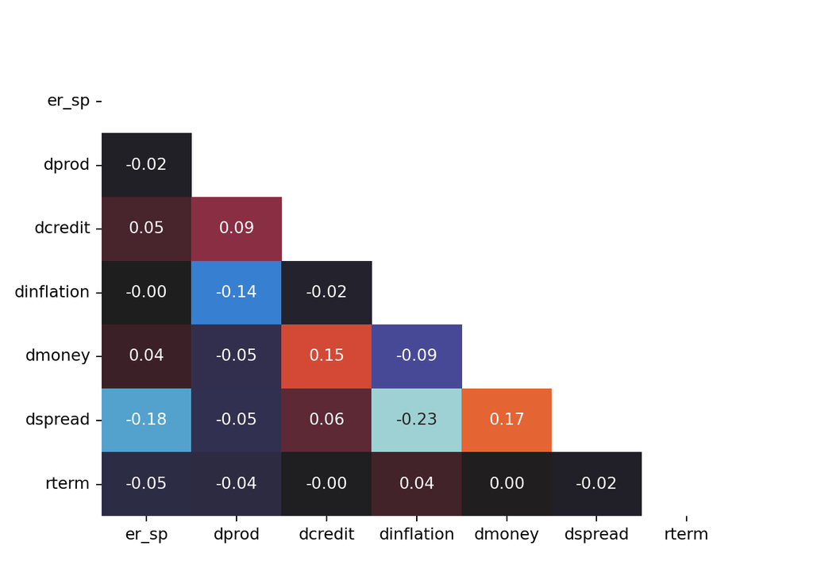

```python
plt.figure(5)
sns.heatmap(dataX.corr(), vmin=-0.25, vmax=0.25, center=0, annot=True, fmt='.2f', mask=~np.tri(dataX.corr().shape[1], k=-1, dtype=bool), cbar=False)
plt.show()
```